# Profiling R Code

```r
# we will need these packages
library(tidyverse)
library(profvis)
library(bench)
```

# Profiling

[Donald Knuth](https://en.wikipedia.org/wiki/Donald_Knuth) has famously said

> The real problem is that programmers have spent far too much time worrying about efficiency in the wrong places and at the wrong times; premature optimization is the root of all evil (or at least most of it) in programming.

We consider this example of simple linear regression,

```r
generate_and_fit <- function(n) {
  x <- runif(n)
  y <- runif(n)
  fit <- lm(y ~ x)
  coef(fit)
}
```

```r
generate_and_fit(1e7) #  it is quite slow
```

```
##  (Intercept)            x
## 5.000488e-01 7.080805e-06
```

### `system.time`

The easier tool to do profiling perhaps is the `system.time` function. It reports the amount of time elapsed.

```r
system.time(generate_and_fit(1e7))
```

```
##    user  system elapsed
##   2.199   0.461   3.061
```

See https://en.wikipedia.org/wiki/Time_(Unix)#User_time_vs_system_time for the differences between user and system times. (TLDR, they are not very relevant to us.)

### `Rprof`

`Rprof()` keeps track of the function call stack at regularly sampled intervals and tabulates how much time is spent inside each function.

```r
Rprof()
generate_and_fit(1e7)
```

```
##  (Intercept)            x
## 0.4998302947 0.0003658326
```

```r
Rprof(NULL)
result <- summaryRprof()
```

```r
result$by.self
```

```
##                         self.time self.pct total.time total.pct
## "runif"                      0.72    30.51       0.72     30.51
## "lm.fit"                     0.52    22.03       0.70     29.66
## "anyDuplicated.default"      0.40    16.95       0.40     16.95
## "[.data.frame"               0.22     9.32       0.64     27.12
## "c"                          0.18     7.63       0.18      7.63
## "na.omit.data.frame"         0.14     5.93       0.86     36.44
## ".External2"                 0.06     2.54       0.92     38.98
## "is.na"                      0.06     2.54       0.06      2.54
## "!"                          0.02     0.85       0.02      0.85
## "any"                        0.02     0.85       0.02      0.85
## "model.response"             0.02     0.85       0.02      0.85
```

```r
result$by.total
```

```
##                         total.time total.pct self.time self.pct
## "block_exec"                  2.36    100.00      0.00     0.00
## "call_block"                  2.36    100.00      0.00     0.00
## "eval"                        2.36    100.00      0.00     0.00
## "evaluate_call"               2.36    100.00      0.00     0.00
## "evaluate::evaluate"          2.36    100.00      0.00     0.00
## "evaluate"                    2.36    100.00      0.00     0.00
## "generate_and_fit"            2.36    100.00      0.00     0.00
## "handle"                      2.36    100.00      0.00     0.00
## "in_dir"                      2.36    100.00      0.00     0.00
## "knitr::knit"                 2.36    100.00      0.00     0.00
## "process_file"                2.36    100.00      0.00     0.00
## "process_group.block"         2.36    100.00      0.00     0.00
## "process_group"               2.36    100.00      0.00     0.00
## "rmarkdown::render"           2.36    100.00      0.00     0.00
## "timing_fn"                   2.36    100.00      0.00     0.00
## "withCallingHandlers"         2.36    100.00      0.00     0.00
## "withVisible"                 2.36    100.00      0.00     0.00
## "lm"                          1.64     69.49      0.00     0.00
## ".External2"                  0.92     38.98      0.06     2.54
## "model.frame.default"         0.88     37.29      0.00     0.00
## "stats::model.frame"          0.88     37.29      0.00     0.00
## "na.omit.data.frame"          0.86     36.44      0.14     5.93
## "na.omit"                     0.86     36.44      0.00     0.00
## "runif"                       0.72     30.51      0.72    30.51
## "lm.fit"                      0.70     29.66      0.52    22.03
## "[.data.frame"                0.64     27.12      0.22     9.32
## "["                           0.64     27.12      0.00     0.00
## "anyDuplicated.default"       0.40     16.95      0.40    16.95
## "anyDuplicated"               0.40     16.95      0.00     0.00
## "c"                           0.18      7.63      0.18     7.63
## "is.na"                       0.06      2.54      0.06     2.54
## "model.matrix.default"        0.04      1.69      0.00     0.00
## "model.matrix"                0.04      1.69      0.00     0.00
## "!"                           0.02      0.85      0.02     0.85
## "any"                         0.02      0.85      0.02     0.85
## "model.response"              0.02      0.85      0.02     0.85
```

> These are the basic computing engines called by lm used to fit linear models. These should usually not be used directly unless by experienced users.

### Visualising profiles

There are two ways to use `profvis`:

- From the Profile menu in RStudio.
- Use the `profvis` function

```r
profvis(generate_and_fit(1e7))
```

[interactive chart not shown]

### Memory profiling

When an object in R is not referenced by any other objects, it will get GC’ed (garbage collected). If `GC` is taking a lot of time, it’s usually an indication that you’re creating many short-lived objects.

```r
x <- runif(10000000)
x <- NULL
```

```r
# suppose `f` is a function given to you.
n <- 1e4
draw <- sample.int(n, 10)
f <- function(x) x %in% draw
```

```r
profvis({
  x <- logical()
  for (i in 1:n) {
    x <- c(x, f(i))
  }
})
```

[interactive chart not shown]

Each time when `x <- c(x, i)` is executed, the previous `x` is de-referenced and marked as pending to be GC’ed. R will GC those `x`’s at some point down the line.

So a better approach? In the following code, the vector `x` is pre-allocated.

```r
profvis({
  x <- logical(n)
  for (i in 1:n) {
    x[i] <- f(i)
  }
},
interval = 0.0005)
```

```
## Intervals smaller than ~5ms will probably not result in accurate timings.
```

[interactive chart not shown]

## Microbenchmark

A micro benchmark is a measurement of the performance of a very small piece of code.

The following code compares the speed of two approaches to computing a square root.

```r
x <- runif(100)
bench::mark(
  sqrt(x),
  x^0.5
)
```

```
## # A tibble: 2 x 6
##   expression      min   median `itr/sec` mem_alloc `gc/sec`
##   <bch:expr> <bch:tm> <bch:tm>     <dbl> <bch:byt>    <dbl>
## 1 sqrt(x)       422ns    491ns  1120420.      848B        0
## 2 x^0.5        2.56µs    2.7µs   317994.      848B        0
```

```r
bench::mark(
  sqrt(x),
  x^0.5,
  relative = TRUE
)
```

```
## # A tibble: 2 x 6
##   expression   min median `itr/sec` mem_alloc `gc/sec`
##   <bch:expr> <dbl>  <dbl>     <dbl>     <dbl>    <dbl>
## 1 sqrt(x)     1      1         2.72         1      NaN
## 2 x^0.5       6.18   5.58      1            1      NaN
```

`sqrt(x)` is is about 5x faster than `x ^ 0.5`

### Revisit the draw example.

```r
n <- 1e5
res <- bench::mark(
  `for loop` = {
    x <- logical(n)
    for (i in 1:n) {
      x[i] <- f(i)
    }
    x
  },
  map = map_lgl(1:n, f),
  sapply = sapply(1:n, f)
)
```

### A simple linear regression example

We want to compare several ways to perform simple linear regression.

- pure R function
- Rcpp
- `lm`

```r
slr <- function(x, y) {
  mux <- mean(x)
  muy <- mean(y)
  sxy <- sum((x - mux) * (y - muy))
  sxx <- sum((x - mux)^2)
  slope <- sxy / sxx
  intercept <- muy - slope * mux
  c(intercept, slope)
}
```

```cpp
#include <Rcpp.h>
using namespace Rcpp;

// [[Rcpp::export]]
NumericVector slr_cpp(NumericVector x, NumericVector y) {
  double mux = mean(x);
  double muy = mean(y);
  double sxy = sum((x - mux)*(y - muy));
  double sxx = sum(pow(x - mux, 2));
  double slope = sxy / sxx;
  double intercept = muy - slope * mux;
  return NumericVector::create(intercept, slope);
}
```

Remark: No worries, we will cover Rcpp later.

```r
x <- runif(1e7)
y <- runif(1e7)

(result <- bench::mark(
  slr = slr(x, y),
  slr_cpp = slr_cpp(x, y),
  lm = coef(lm(y ~ x)),
  check = FALSE,
  iterations = 3
))
```

```
## # A tibble: 3 x 6
##   expression      min   median `itr/sec` mem_alloc `gc/sec`
##   <bch:expr> <bch:tm> <bch:tm>     <dbl> <bch:byt>    <dbl>
## 1 slr        119.22ms 128.85ms     5.14   228.88MB     1.71
## 2 slr_cpp     67.52ms  68.14ms    14.7      2.49KB     0
## 3 lm            1.69s    1.69s     0.578    1.69GB     2.50
```

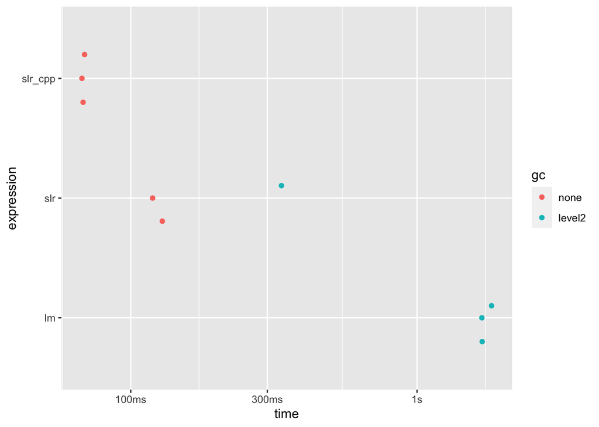

```r
autoplot(result)
```

There are three levels of collections. - level 0 collects only the youngest generation - level 1 collects the two youngest generations - level 2 collects all generations.

After 20 level-0 collections the next collection is at level 1, and after 5 level-1 collections at level 2.

# Reference

- Advanced R https://adv-r.hadley.nz/perf-measure.html
- R Programming for Data Science https://bookdown.org/rdpeng/rprogdatascience/profiling-r-code.html